# **TUGAS MPDW PERTEMUAN 6**

Joshua Bryan Wijaya~G1401231082

2025-10-1

# **LIBRARY**

```r
library(forecast)
```

```r
library(graphics)
library(TTR)
library(TSA)
library(dplyr)
library(rio)
library(readxl)
library(ggplot2)
library(tsibble)
library(tseries)
library(MASS)
```

# **DATA**

```r
data <- read_xlsx("C:/JOSHUA BRYAN WIJAYA/SEMESTER 5/MPDW/Joshua.xlsx")
summary(data)
```

```
##       date                       temp_mean          part
##  Min.   :2024-12-20 00:00:00   Min.   :24.00   Min.   :4
##  1st Qu.:2025-02-20 06:00:00   1st Qu.:25.40   1st Qu.:4
##  Median :2025-04-23 12:00:00   Median :25.80   Median :4
##  Mean   :2025-04-23 12:00:00   Mean   :25.81   Mean   :4
##  3rd Qu.:2025-06-24 18:00:00   3rd Qu.:26.30   3rd Qu.:4
##  Max.   :2025-08-26 00:00:00   Max.   :27.80   Max.   :4
##                                NA's   :2
```

```r
head(data)
```

```
## # A tibble: 6 × 3
##   date                temp_mean  part
##   <dttm>                  <dbl> <dbl>
## 1 2024-12-20 00:00:00      25.9     4
## 2 2024-12-21 00:00:00      26.2     4
## 3 2024-12-22 00:00:00      25.5     4
## 4 2024-12-23 00:00:00      25.6     4
## 5 2024-12-24 00:00:00      25       4
## 6 2024-12-25 00:00:00      25.3     4
```

Data yang digunakan adalah data rataan temperatur di Kab. Bogor, dimulai dari rentang waktu 20 Desember 2024 hingga 26 Agustus 2025

# **EKSPLORASI DATA**

```r
data <- data %>% dplyr::select(date,temp_mean)
str(data)
```

```
## tibble [250 × 2] (S3: tbl_df/tbl/data.frame)
##  $ date     : POSIXct[1:250], format: "2024-12-20" "2024-12-21" ...
##  $ temp_mean: num [1:250] 25.9 26.2 25.5 25.6 25 25.3 26.4 26.5 27.2 26.2 ...
```

```r
dim(data)
```

```
## [1] 250   2
```

```r
colSums(is.na(data))
```

```
##      date temp_mean
##         0         2
```

```r
data[!complete.cases(data), ]
```

```
## # A tibble: 2 × 2
##   date                temp_mean
##   <dttm>                  <dbl>
## 1 2025-08-25 00:00:00        NA
## 2 2025-08-26 00:00:00        NA
```

Ditemukan 2 amatan yang null alias tidak memiliki nilai. Selanjutnya, untuk menangani hal ini, akan dilakukan imputasi nilai menggunakan rataan dari seluruh nilai temp_mean.

# **IMPUTASI DATA KOSONG**

```r
mean_val <- mean(data$temp_mean, na.rm = TRUE)
data$temp_mean[is.na(data$temp_mean)] <- mean_val

colSums(is.na(data))
```

```
##      date temp_mean
##         0         0
```

```r
data[!complete.cases(data), ]
```

```
## # A tibble: 0 × 2
## # ℹ 2 variables: date <dttm>, temp_mean <dbl>
```

Setelah dilakukan imputasi data, tidak lagi ditemukan nilai kosong pada data. Imputasi nilai kosong dilakukan dengan menggunakan nilai rataan dari Yt(temperature_mean). Sekarang data sudah siap untuk dianalisis dengan metode smoothing

# **TEST X TRAIN**

```r
n <- nrow(data)
n_train <- floor(0.8*n)
training_ma <- data[1:n_train,]
testing_ma <- data[(n_train+1):n,]
train_ma.ts<- ts(training_ma$temp_mean)
test_ma.ts<- ts(testing_ma$temp_mean)
```

Data di split dengan rasio data latih:data uji 80:20. Selanjutnya, untuk pengecekan kestasioneran data, akan dilakukan hanya pada data latih saja (karena data latih yang digunakan untuk membentuk model kedepannya).

# **UJI DATA SECARA KESELURUHAN**

# **PLOT DERET WAKTU**

```r
data.ts <- ts(data$temp_mean)
```

```r
head(data.ts)
```

```
## Time Series:
## Start = 1
## End = 6
## Frequency = 1
## [1] 25.9 26.2 25.5 25.6 25.0 25.3
```

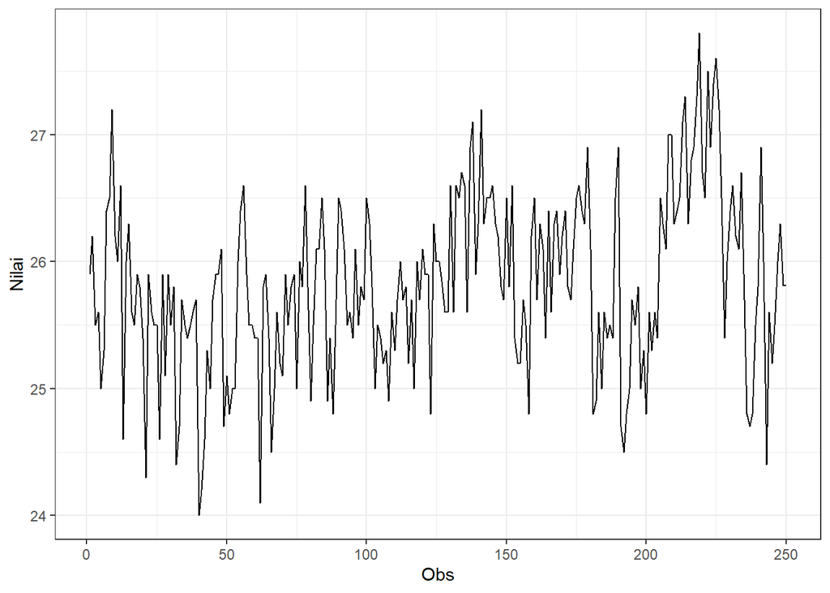

```r
plot_data <- data.ts |> as_tsibble() |>
  ggplot(aes(x = index, y = value)) + geom_line() + theme_bw() +
  xlab("Obs") + ylab("Nilai")
plot_data
```

Terlihat pada plot time series, data memiliki tren naik dari periode 50 hingga seterusnya. Kemungkinan besar, data tidak stasioner pada rataannya, namun stasioner pada ragam, karena terlihat bahwa amplitudo data di tiap periodenya cukup konstan.

# **EKSPLORASI KESTASIONERAN DATA**

## **Kestasioneran dalam Rataan**

```r
mean(data.ts)
```

```
## [1] 25.8129
```

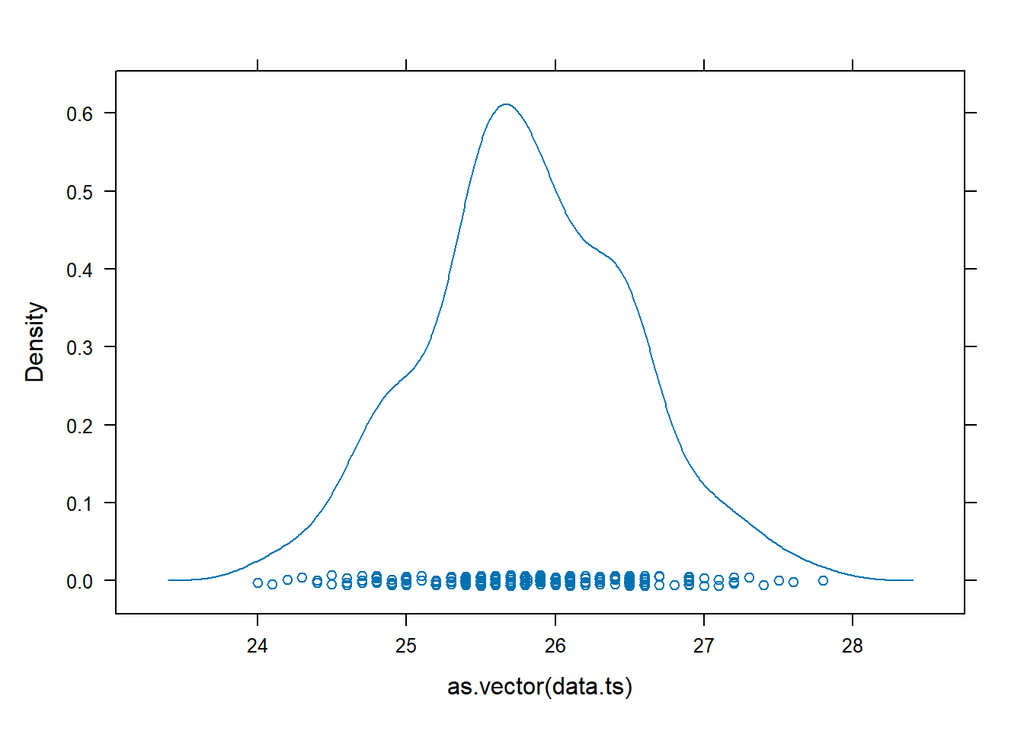

```r
lattice::densityplot(as.vector(data.ts))
```

Diperoleh nilai rata-rata sebesar 25.81. Dari density plot data, terlihat bahwa data cenderung berkumpul di angka 25.5 hingga 26. Ini bisa jadi pertanda baik untuk kestasioneran dalam rataan. Namun, uji lanjutan tetap perlu dilakukan.

## **Plot ACF**

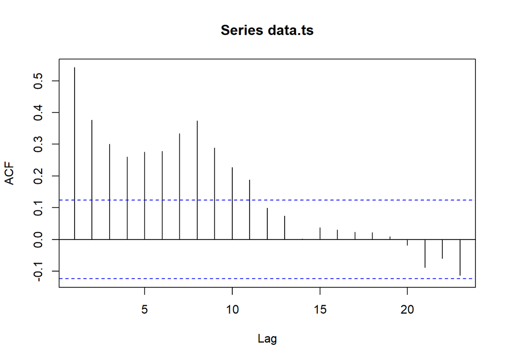

```r
acf(data.ts)
```

Terlihat bahwa plot ACF di atas membentuk pola *tails off* cukup panjang (turun perlahan). Hasil plot ACF baru terlihat tidak signifikan pada lag 12, dan dari lag 19 hingga seterusnya, terlihat adanya kecenderungan untuk membentuk pola gelombang sinus.Dari sini, terlihat bahwa data masih punya kecenderungan pola tren yang tentunya harus diselidiki lebih lanjut dengan uji formal.

## **Uji ADF**

$H_0$ : Data Tidak Stasioner dalam Rataan  
$H_1$ : Data Stasioner dalam Rataan

```r
tseries::adf.test(data.ts)
```

```
##
##  Augmented Dickey-Fuller Test
##
## data:  data.ts
## Dickey-Fuller = -3.4032, Lag order = 6, p-value = 0.05449
## alternative hypothesis: stationary
```

Terlihat bahwa hasil uji ADF menunjukkan nilai $P - Value > 0.05$. Sehingga keputusan yang diambil adalah tak cukup bukti untuk tolak $H_0$. Artinya, **data tidak stasioner dalam rataan**. Hsail ini sesuai dengan plot time series dan plot ACF sebelumnya.

# **EKSPLORASI KESTASIONERAN DALAM RAGAM**

```r
index <- seq(1:250)
bc <- boxcox(
  data.ts ~ index,
  lambda = seq(-7, 7, by = 0.01)
)
```

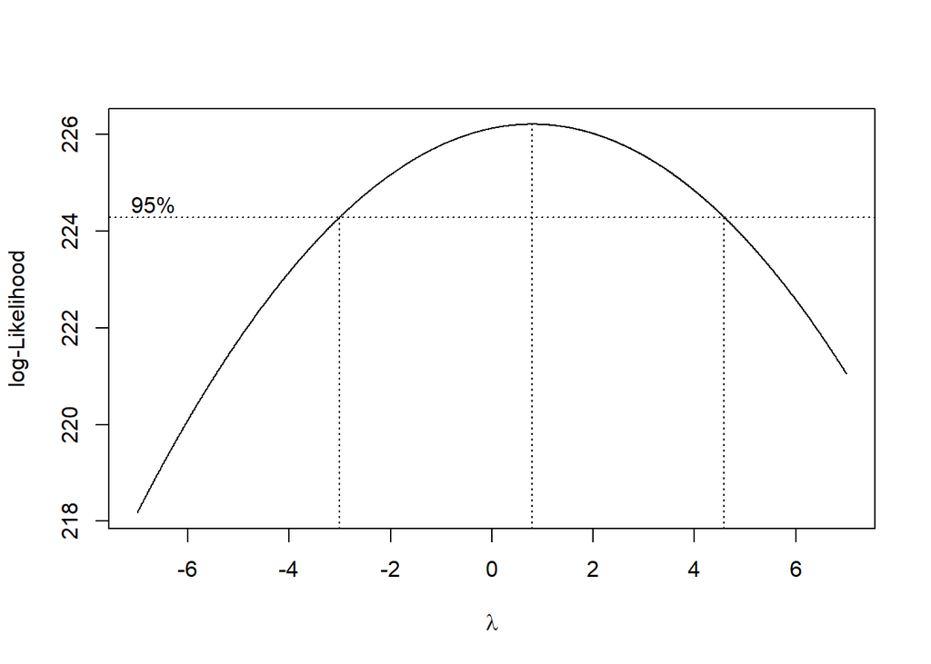

```r
lambda <- bc$x[which.max(bc$y)]
cat("Lambda Optimum: ", lambda)
```

```
## Lambda Optimum:  0.79
```

```r
ci_lambda <- bc$x[bc$y > max(bc$y) - 0.5 * qchisq(0.95, 1)]
ci_lower <- min(ci_lambda)
ci_upper <- max(ci_lambda)

c(Batas_Bawah = ci_lower, Batas_Atas = ci_upper)
```

```
## Batas_Bawah  Batas_Atas
##       -3.00        4.58
```

Terlihat bahwa selang kepercayaan untuk lambda memiliki batas bawah -3, dan batas atas 4.59. Hal ini menunjukkan bahwa **lambda = 1** terdapat dalam selang. Hasil ini dapat diartikan bahwa **data stasioner dalam ragam**

## **Partisi Data**

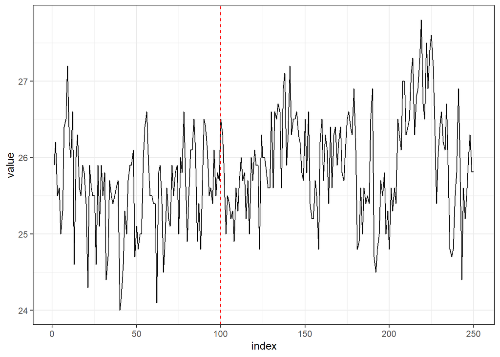

```r
data.ts |>
  as_tsibble(index = index) |>
  ggplot(aes(x = index, y = value)) +
  geom_line() +
  geom_vline(xintercept = 100, linetype = "dashed", color = "red") +
  theme_bw()
```

### Partisi 1

```r
data_partisi1 <- data.ts[1:100] |> ts()
mean(data_partisi1)
```

```
## [1] 25.574
```

```r
var(data_partisi1)
```

```
## [1] 0.3734586
```

### Partisi 2

```r
data_partisi2 <- data.ts[101:250] |> ts()
mean(data_partisi2)
```

```
## [1] 25.97217
```

```r
var(data_partisi2)
```

```
## [1] 0.4901601
```

Setelah di grid, anehnya rataan dari kedua bagian justru hampir sama (seakan-akan data stasioner dalam rataan). Kemudian, untuk ragamnya terlihat ada perubahan yang cukup besar.

# **PENANGANAN I : DIFFERENCING**

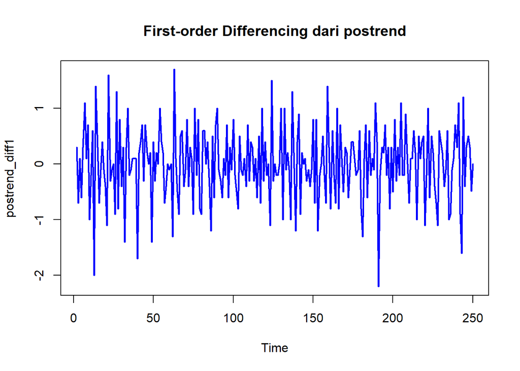

```r
postrend_diff1 <- diff(data.ts, differences = 1)
ts.plot(postrend_diff1,
        main = "First-order Differencing dari postrend",
        col = "blue", lwd = 2)
```

```r
length(postrend_diff1)
```

```
## [1] 249
```

Secara definisi, melakukan differencing terhadap model berarti:
$$y_t= X_t -X_{t-1}$$
.
Untuk differencing periode pertama, kita tidak memiliki data untuk diselisihkan, maka dari itu, proses selisihnya baru bisa dimulai dari lag kedua hingga seterusnya. Karena itulah, panjang data hasil differencing berkurang 1. Selan itu, hasil plot setelah *differencing* ordo 1 sangatlah memuaskan, dimana data terlihat sudah memiliki rataan konstan, tetapi amplitudo setiap periodenya justru terlihat berbeda.

## **Plot ACF Setelah Penanganan**

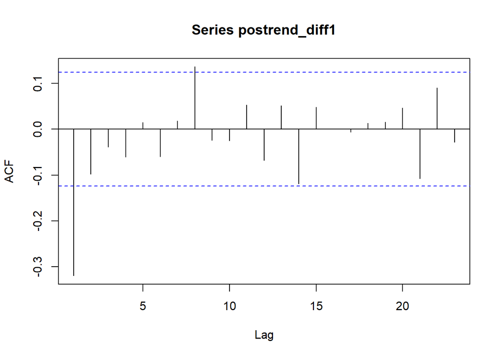

```r
acf(postrend_diff1)
```

Setelah dilakukan differencing ordo 1, terlihat bahwa plot ACF di atas tidak mengalami penurunan perlahan. Hasil plot ACF baru langsung tidak signifikan pada lag 2. Pattern data juga sudah berosilasi di sekitar angka 0 dan hanya sedikit lag saja yang signifikan pada plot ACF. ini merupakan pertanda bahwa **data sudah stasioner dalam rataan**.

## **Uji ADF setelah Penanganan**

$H_0$ : Data Tidak Stasioner dalam Rataan  
$H_1$ : Data Stasioner dalam Rataan

```r
tseries::adf.test(postrend_diff1)
```

```
##
##  Augmented Dickey-Fuller Test
##
## data:  postrend_diff1
## Dickey-Fuller = -10.632, Lag order = 6, p-value = 0.01
## alternative hypothesis: stationary
```

Terlihat bahwa hasil uji ADF menunjukkan nilai $P - Value < 0.05$ (bahkan lebih kecil seharusnya dari 0.1, tapi uji ADF di R hanya menampilkan nilai 0.01 keatas). Sehingga keputusan yang diambil adalah cukup bukti untuk tolak $H_0$. Artinya, **data stasioner dalam rataan**. Hsail ini sesuai dengan plot time series dan plot ACF sebelumnya.

## **Rataan Partisi setelah penanganan**

### Partisi 1

```r
data_partisi1 <- postrend_diff1[1:100] |> ts()
mean(data_partisi1)
```

```
## [1] 0.004
```

```r
var(data_partisi1)
```

```
## [1] 0.4888727
```

### Partisi 2

```r
data_partisi2 <- postrend_diff1[101:249] |> ts()
mean(data_partisi2)
```

```
## [1] -0.003269106
```

```r
var(data_partisi2)
```

```
## [1] 0.4129437
```

## **Kestasioneran dalam Varian setelah penanganan**

```r
min(postrend_diff1)
```

```
## [1] -2.2
```

```r
postrend_shift <- postrend_diff1 + 3
index <- seq_along(postrend_shift)

bc <- boxcox(postrend_shift ~ index,
             lambda = seq(-4, 8, by = 0.01))
```

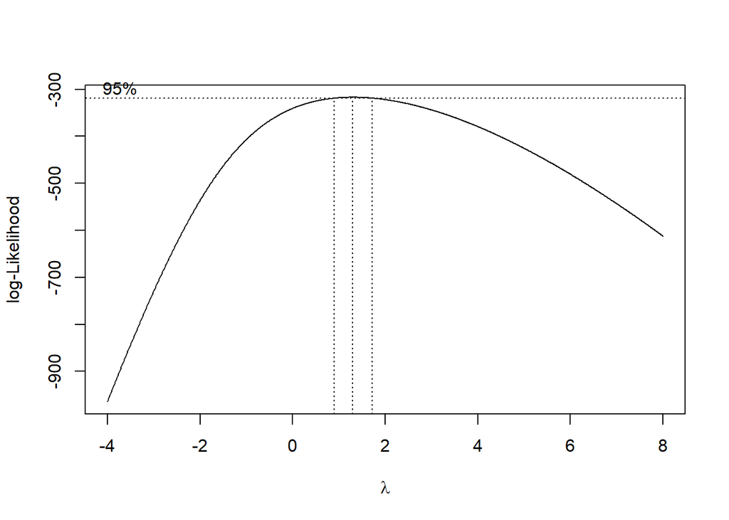

```r
lambda <- bc$x[which.max(bc$y)]
cat("Lambda Optimum: ", lambda)
```

```
## Lambda Optimum:  1.3
```

```r
ci_lambda <- bc$x[bc$y > max(bc$y) - 0.5 * qchisq(0.95, 1)]
ci_lower <- min(ci_lambda)
ci_upper <- max(ci_lambda)

c(Batas_Bawah = ci_lower, Batas_Atas = ci_upper)
```

```
## Batas_Bawah  Batas_Atas
##        0.90        1.72
```

Setelah dilakukan differencing ordo 1, nilai data ada yang negatif, karena itu, sebelum dialkukan uji box-cox, nilai y digeser dlu 3 satuan keatas. Hal ini tidak akan memengaruhi keragaman pada data. Selanjutnya, karena nilai lambda = 1 terdapat pada selang kepercayaan lambda, maka **data stasioner dalam ragam**.

# **UJI DATA LATIH SAJA**

```r
head(train_ma.ts)
```

```
## Time Series:
## Start = 1
## End = 6
## Frequency = 1
## [1] 25.9 26.2 25.5 25.6 25.0 25.3
```

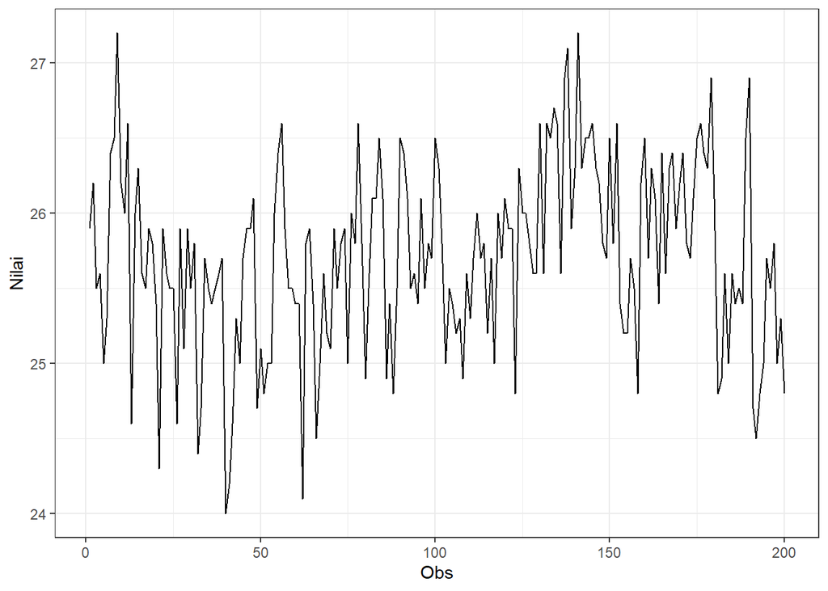

```r
plot_data <- train_ma.ts |> as_tsibble() |>
  ggplot(aes(x = index, y = value)) + geom_line() + theme_bw() +
  xlab("Obs") + ylab("Nilai")
plot_data
```

Terlihat pada plot time series, data train (data latih) cenderung bergerak di sekitar nilai tengah yang sama, serta fluktuasi/amplitudo di setiap amatan terlihat konstan. Hasil ini mendindikasikan bahwa data cenderung stasioner dalam rataan dan ragam.

# **EKSPLORASI KESTASIONERAN DATA LATIH**

## **Kestasioneran dalam Rataan**

```r
mean(train_ma.ts)
```

```
## [1] 25.706
```

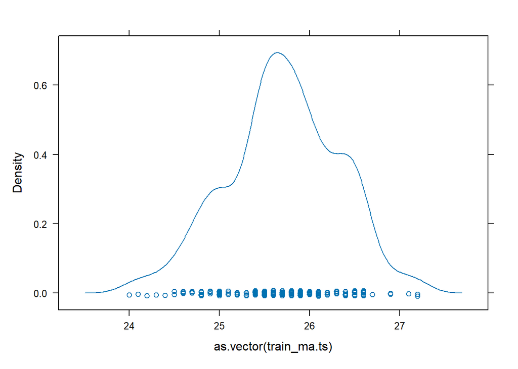

```r
lattice::densityplot(as.vector(train_ma.ts))
```

Diperoleh nilai rata-rata sebesar 25.706. Dari density plot data, terlihat bahwa data cenderung berkumpul di angka 25.5 hingga 26. Ini bisa jadi pertanda baik untuk kestasioneran dalam rataan. Namun, uji lanjutan tetap perlu dilakukan.

## **Plot ACF**

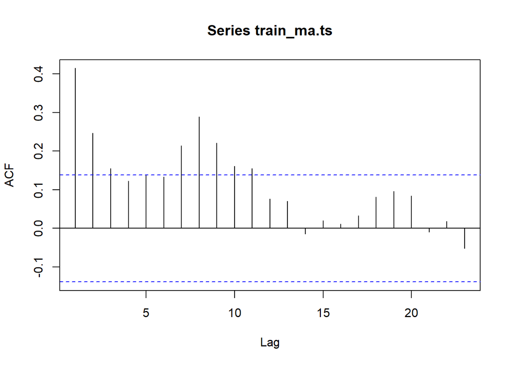

```r
acf(train_ma.ts)
```

Terlihat bahwa plot ACF di atas membentuk pola *tails off* cukup panjang (turun perlahan). Hasil plot ACF baru terlihat tidak signifikan pada lag 4, dan dari lag 19 hingga seterusnya, terlihat adanya kecenderungan untuk membentuk pola gelombang sinus.Dari sini, terlihat bahwa data masih punya kecenderungan pola tren yang tentunya harus diselidiki lebih lanjut dengan uji formal. Dan Plot ACF terlihat dimulai dari lag 1, bukan lag 0.

## **Uji ADF**

$H_0$ : Data Tidak Stasioner dalam Rataan  
$H_1$ : Data Stasioner dalam Rataan

```r
tseries::adf.test(train_ma.ts)
```

```
##
##  Augmented Dickey-Fuller Test
##
## data:  train_ma.ts
## Dickey-Fuller = -4.0634, Lag order = 5, p-value = 0.01
## alternative hypothesis: stationary
```

Terlihat bahwa hasil uji ADF menunjukkan nilai $P - Value < 0.05$. Sehingga keputusan yang diambil adalah tolak $H_0$. Artinya, **data stasioner dalam rataan**. Hasil ini sedikit berbeda dengan plot time series dan plot ACF sebelumnya.

# **KESTASIONERAN DATA LATIH DALAM RAGAM**

```r
index <- seq(1:200)
bc <- boxcox(
  train_ma.ts ~ index,
  lambda = seq(-7, 12, by = 0.01)
)
```

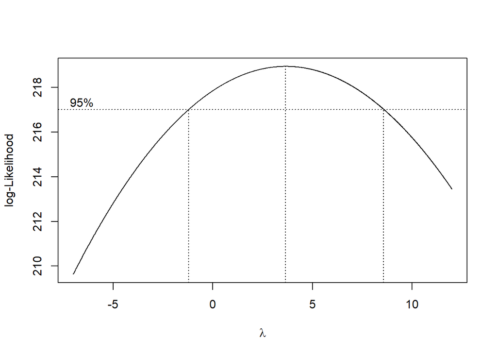

```r
lambda <- bc$x[which.max(bc$y)]
cat("Lambda Optimum: ", lambda)
```

```
## Lambda Optimum:  3.66
```

```r
ci_lambda <- bc$x[bc$y > max(bc$y) - 0.5 * qchisq(0.95, 1)]
ci_lower <- min(ci_lambda)
ci_upper <- max(ci_lambda)

c(Batas_Bawah = ci_lower, Batas_Atas = ci_upper)
```

```
## Batas_Bawah  Batas_Atas
##       -1.20        8.57
```

Terlihat bahwa selang kepercayaan untuk lambda memiliki batas bawah -1.2, dan batas atas 8.57. Hal ini menunjukkan bahwa **lambda = 1** terdapat dalam selang. Hasil ini dapat diartikan bahwa **data stasioner dalam ragam**

# **KESIMPULAN**

Diagnosa awal data temperatur Kab.Bogor adalah **stasioner dalam ragam, namun tidak stasioner dalam rataan**. Penanganan yang efektif adalah *differencing*. Ternyata, differencing ordo 1 sudah cukup untuk membuat data stasioner dalam rataan, serta tentunya tetap mempertahankan kestasionerannya dalam ragam. Dilain sisi, jika data keseluruhan di split menjadi data latih dan data uji dengan rasio 80:20, ditemukan bahwa data latih sudah stasiner dalam rataan dan ragam (tanpa perlu penanganan apapun).